# The Federalist Papers: Clustering Analysis

# Exploratory Data Analysis

Summary of the 85 Papers by Author

| Author | Frequency |
| --- | --- |
| AH | 51 |
| COL | 3 |
| DIS | 12 |
| JJ | 5 |
| JM | 14 |

Next, all the function words that are included in this dataset has been summarized in the following table. There are 70 function words in this dataset, which refers to the common words people use without much deliberation. Those function words reflects the unique writing habits and styles of the author. which provide us with great insights into determining the authorship of the disputed papers.

Table of Function Words in the Dataset

| a | all | also | an | and | any | are | as | at | be |
| --- | --- | --- | --- | --- | --- | --- | --- | --- | --- |
| been | but | by | can | do | down | even | every | for. | from |
| had | has | have | her | his | if. | in. | into | is | it |
| its | may | more | must | my | no | not | now | of | on |
| one | only | or | our | shall | should | so | some | such | than |
| that | the | their | then | there | things | this | to | up | upon |
| was | were | what | when | which | who | will | with | would | your |

Statistics Summary of 3 Randomly Selected Variables

|  | than | upon | into |
| --- | --- | --- | --- |
|  | Min. :-1.62803 | Min. :-1.08383 | Min. :-1.2603 |
|  | 1st Qu.:-0.61221 | 1st Qu.:-1.08383 | 1st Qu.:-0.7588 |
|  | Median :-0.03665 | Median :-0.04626 | Median :-0.1372 |
|  | Mean : 0.00000 | Mean : 0.00000 | Mean : 0.0000 |
|  | 3rd Qu.: 0.32198 | 3rd Qu.: 0.77377 | 3rd Qu.: 0.5301 |
|  | Max. : 4.02417 | Max. : 2.88815 | Max. : 4.2276 |
|  | Sds : 1 | Sds : 1 | Sds : 1 |

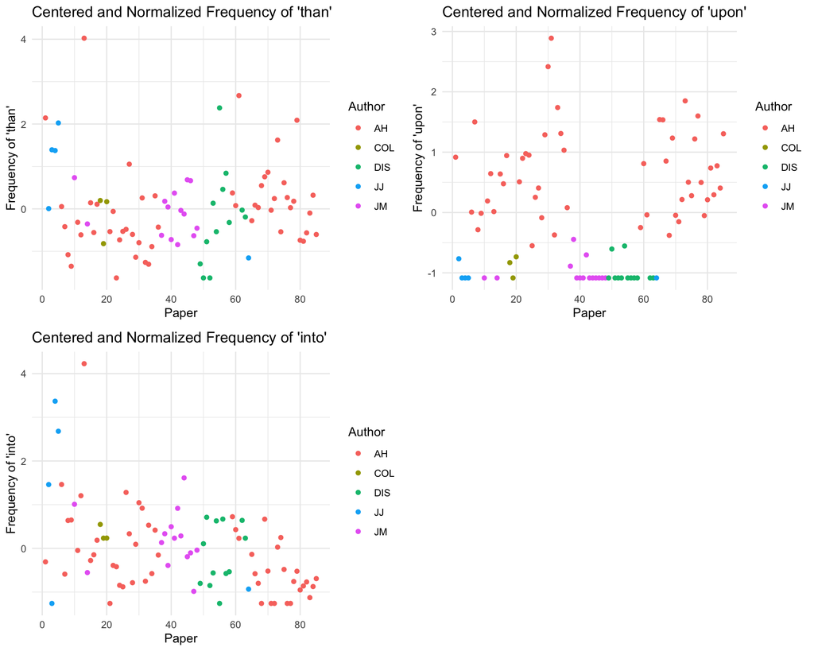

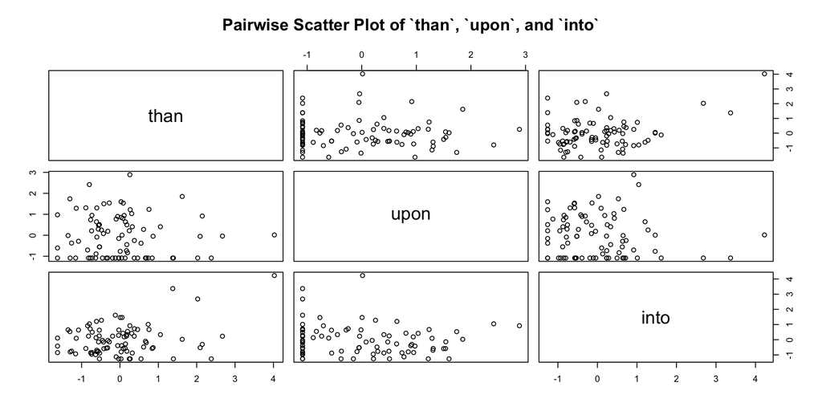

Since `upon` seems to do a great job distinguishing James Madison’s writing habit and style, we decided to compare the frequency of the word `upon` in Alexander Hamilton’s writing and James Madison’s writing to see how different their writing styles can be.

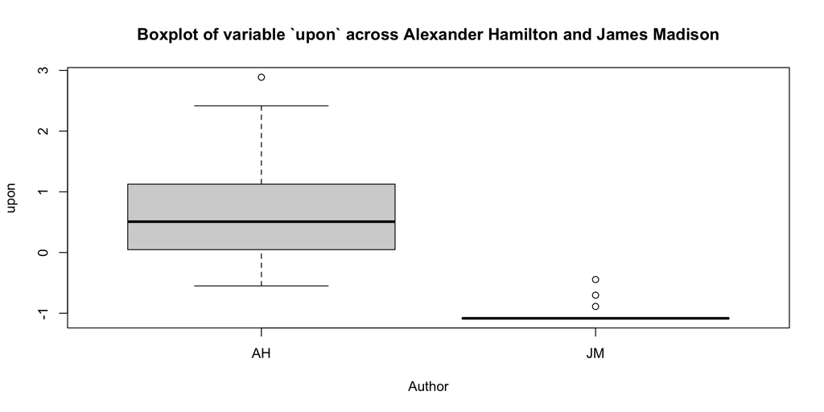

The null hypothesis for the test is that the means of `upon` are equal in Alexander Hamilton’s and James Madison’s writing. The alternate hypothesis for the test is that means are not equal.

Welch’s Two Sample t-test

| Key Statistics | Values |
| --- | --- |
| t | 14.354 |
| df | 62.985 |
| p-value | < 2.2e-16 |

The p-value we got from this Welch two-sample t-test is less than 0.05, therefore, we rejected the cull hypothesis and concluded that the mean of `upon` is statisticaly different among Alexander Hamilton’s and James Madison’s writings.

# Principal Components Analysis

The dimension of the data is the same as the number of variables in the data set. We want to reduce it because a large number of dimensions complicates our work and adds unnecessary workload. We can reduce the dimension by performing a PCA analysis. PCA is esentially project the observed data into a different axis (PCs) so that the dimension can be reduced. In other words, PCA analysis finds the most important determinants in the dataset that can explain ,most of the variations of the data and help us get rid of the dispensable variables. We conduct PCA for all the numerical variables, and we have scaled the data to have unit variance before applying PCA, which fits to one of the PCA assumptions. Variables that have different scales might dominate, thus disrupts, the PCA.

The first 5 PCs of the data are presented below:

First 5 PCs

|  | PC1 | PC2 | PC3 | PC4 | PC5 |
| --- | --- | --- | --- | --- | --- |
| Standard.Deviation | 2.54076 | 2.2278 | 2.09955 | 1.93672 | 1.73304 |
| Proportion.Explained | 0.09222 | 0.0709 | 0.06297 | 0.05358 | 0.04291 |
| Culmulative.Explained | 0.09222 | 0.1631 | 0.22609 | 0.27968 | 0.32258 |

Here is the visualization of our PCA analysis. Looking at the cumulative percentage of variance explained, we need 26 PC to explain at least 80% of the variation on the data. The PCA does a good job in reducing the dimensionality of the data by eliminating more than 50% of the original variables.

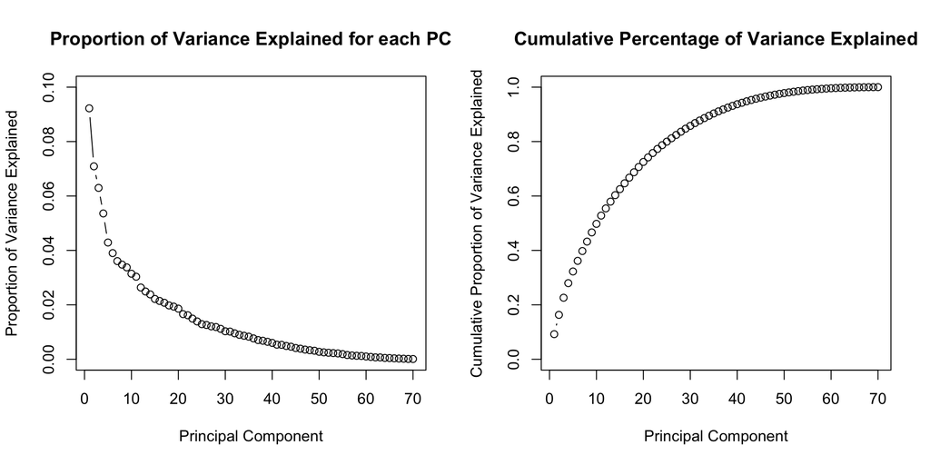

To further our PCA analysis, we conducted pairwise PC plots. We didn’t observe any obvious clusters with the first 3 PCs. It’s not helpful for separating the data. We continue to color the pairwise plots with the authorship. Some data points in the plot are still intermixed, but we can see more patterns of separation of the data. We can see that PC2 and PC3 and still mixed, not being helpful to separate the data. But there are some patterns in PC1 and PC2/3 that we can start to see some distinctions of the data. In general, the blue data points (Disputed) overlaps with green points (James Madison), which shed light on the possible author for the disputed papers is James Madison.

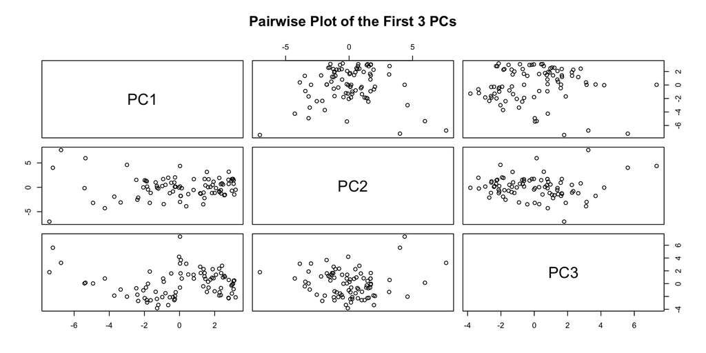

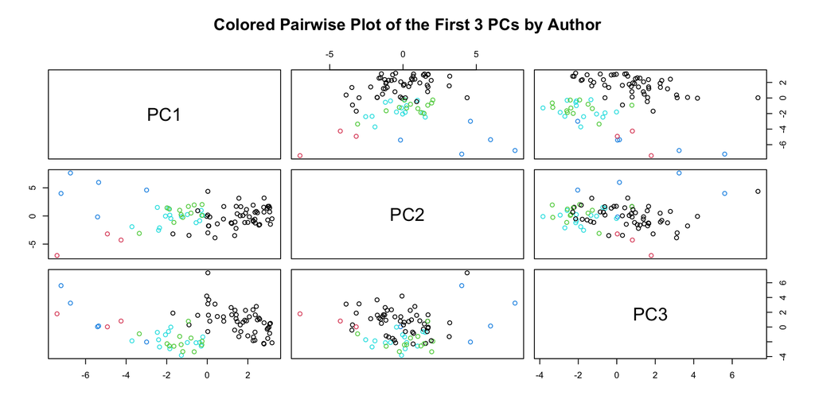

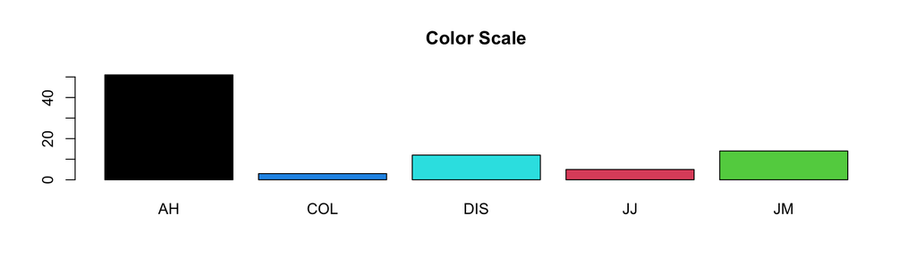

# K-means clustering

Next, we applied K-mean clustering, one type of unsupervised machine learning techniques, to our Federalist Papers dataset to see if we can get more deterministic clusterings.

K-means clustering means that we will group the observations into k groups (clusters) based on their characteristics and use these clusters to label unlabeled observations. A cluster is a group of observations that are similar to each other based on their observed characteristics. This is helpful to this data set because, if we can find some characteristics that sort the authors into distinct clusters, we can use this technique to determine the authors of the disputed papers.

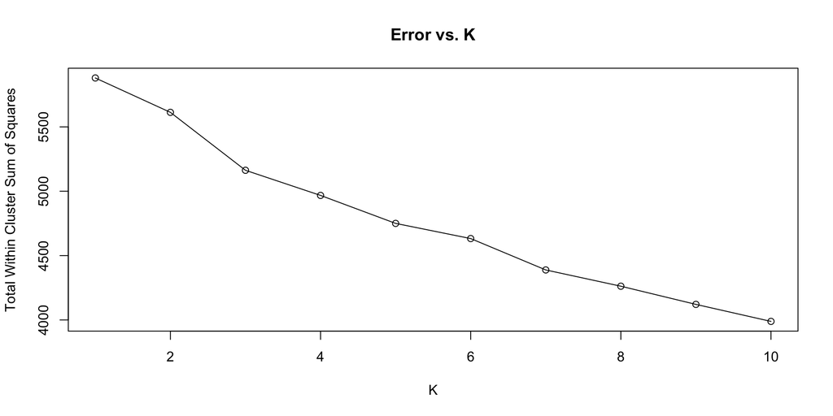

Here’s the first 10 clustering result from the K-mean algorithm:

First 10 Results from K-means clustering

| Paper | Author | Cluster |
| --- | --- | --- |
| 1 | AH | 3 |
| 2 | JJ | 2 |
| 3 | JJ | 4 |
| 4 | JJ | 4 |
| 5 | JJ | 4 |
| 6 | AH | 2 |
| 7 | AH | 3 |
| 8 | AH | 3 |
| 9 | AH | 2 |
| 10 | JM | 1 |

[figure not shown]

The average error for each cluster is then calculated by dividing the within cluster sum of squares error of each cluster by the number of observations of that cluster. The average error table is shown below. It’s evident that the second and third clusters have similar level of error. The first cluster has a lower average error and the fourth cluster has a higher avereage error.

Average Error for Different Clusters

| Cluster | Average Error |
| --- | --- |
| cluster 1 | 48.54699 |
| cluster 2 | 63.36472 |
| cluster 3 | 60.02337 |
| cluster 4 | 83.23596 |

To visualize how the clusters generated by k-means algorithm can be useful, we plotted the first 3 PCs against one another just like what we did for PCA, but color the point of each observation according to the cluster it belongs to. Note that the clusters, in order, are colored: Black, Red, Green, Blue. It’s clear that clusters 1 and 3 are much larger. The PCs visually do a decent job in separating these apart.

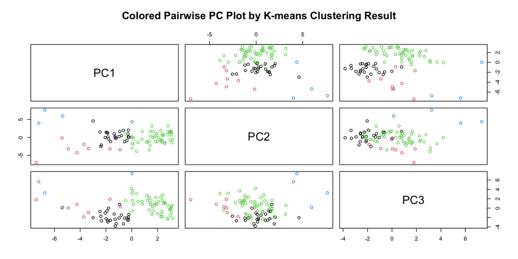

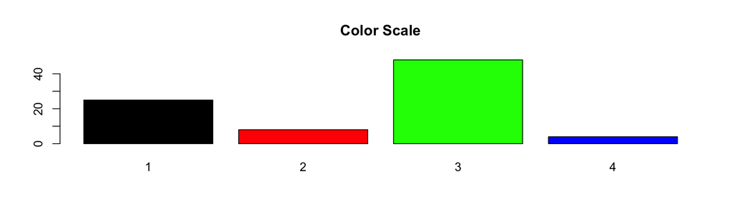

A contigency table has been created to summarize the clusters in our K-mean analysis and determine which cluster correspond to which author:

Contingency Table for K-Means and Obeserved Data

|  | Cluster 1 | Cluster 2 | Cluster 3 | Cluster 4 |
| --- | --- | --- | --- | --- |
| AH | 0 | 2 | 48 | 1 |
| COL | 0 | 3 | 0 | 0 |
| DIS | 11 | 1 | 0 | 0 |
| JJ | 1 | 1 | 0 | 3 |
| JM | 13 | 1 | 0 | 0 |

Therefore, it’s clear that cluster 1 corresponds to James Madison and Disputed; cluster 2 corresponds to Collaboration; cluster 3 corresponds to Alexander Hamilton; cluster 4 corresponds to John Jay. Because the Disputed papers are clearly clustered with the James Madison papers, we believe it is most likely that James Madison authored these papers.

# Hierarchical clustering.

To apply hierarchical clustering, we first removed the categorical variables from the data. Then, we applyed average-linkage hierarchical clustering using euclidean distance to the remaining numerical variables.

The following is the dendogram plot generated by the obtained hierarchical clustering output. Without knowing the anything about the dataset, we would conslude that there are 3 clusters in this dataset. One cluster on the left consists of 13, 1, 18. Another cluster on the right contains 3, 4, 5, 64. The rest of the observations have been grouped ina massive cluster in the middle. We do not want this because it’s clear that there are four clusters in our dataset: AH, JM, JJ, and COL. We will stick with 4 clusters, as used in the k-means analysis.

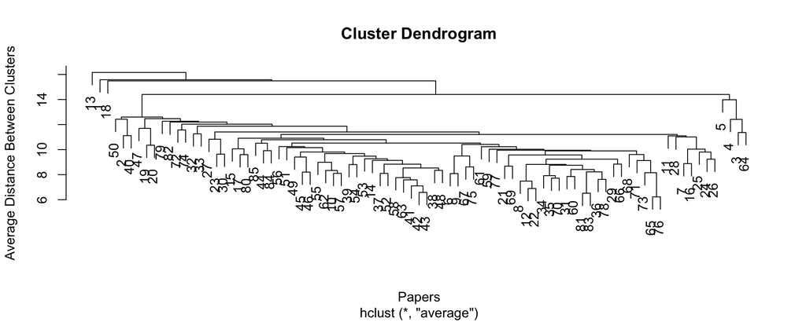

To visualize the separation between the chosen clusters, we added assigned different colors to visualize the size of the clusters. For the light blue cluster to the right, the average distance range is [6,14.5]. For the dark blue cluster adjacent to the light blue cluster, the average distance range is [14.5,15.3].For the second-left green cluster, the average distance range is [15.3,15.5]. And lastly, the red cluster to the left, the average distance range is [14.5,16].

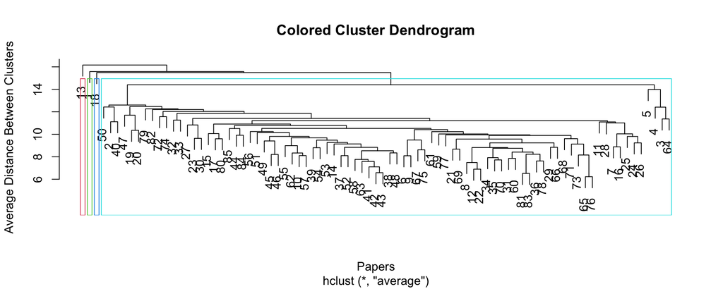

The clusters assigned to the first few rows and columns of the dataset have been presented below. It’s clear that increasing the clusters from 3 to 4 again just puts one paper in its own cluster, and keeps almost all of the data together. This is an early indication that we will not be able to draw conclusions from hierarchical clustering.

First 10 Results from Hierarchical Clustering Result

| Paper | Author | cluster |
| --- | --- | --- |
| 1 | AH | 1 |
| 2 | JJ | 2 |
| 3 | JJ | 2 |
| 4 | JJ | 2 |
| 5 | JJ | 2 |
| 6 | AH | 2 |
| 7 | AH | 2 |
| 8 | AH | 2 |
| 9 | AH | 2 |
| 10 | JM | 2 |

Similar to what we did for k-means, we generate again the pairwise plots of PCA, now coloring the observations according to the clustering provided by the hierarchical clustering output. The clusters are extremely imbalanced. Most data are identified to be cluster 2. Cluster 1,3, and 4 have only 1 observations. This again illustrates that hierarchical is not a good method to use for this Federalist Paper dataset.

[figure not shown]

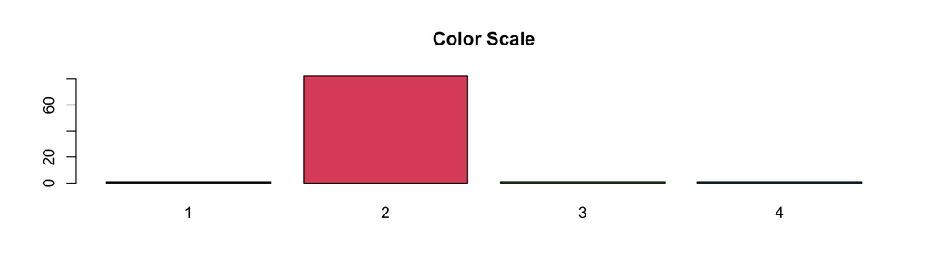

To compare our findings in k-means and hierarchical clustering, another contingency table is generated to compare the output Though we used the same number of clusters for both methods, the resulting clusters are completely unrelated because the hierarchical clustering is so bad. The hierarchical clustering does not include any useful information.

Contingency Table for K-means and Hierarchical Clustering

|  | K.Mean.1 | K.Mean.2 | K.Mean.3 | K.Mean.4 |
| --- | --- | --- | --- | --- |
| Hierarchical.1 | 0 | 0 | 1 | 0 |
| Hierarchical.2 | 25 | 7 | 47 | 3 |
| Hierarchical.3 | 0 | 0 | 0 | 1 |
| Hierarchical.4 | 0 | 1 | 0 | 0 |

# Conclusion

This type of analysis is extremely promising and powerful because it can help us enables us to identify the most likely author of articles, news or messages. It has great applications in real-life: authorship identification can be applied to tasks such as identifying anonymous author, detecting plagiarism or finding ghost writer. As more and more people posting and writing online anonymously, having the ability to identify the author of a piece of writing might gets more and more important.

# Appendix

The code we used to answer the questions have been shown below:

Loading packages:

```r
set.seed(315)
library(kableExtra)
library(tidyverse)
library(tidyr)
library(dplyr)
library(microbenchmark)
library(matrixStats)
library(ggplot2)
library(grid)
library(gridExtra)
```

Q1:

```r
federalist=read.delim("Federalist.txt",header = TRUE, sep = ",", dec = ".")
federalist[1:5,1:6]
```

Q2:

```r
str(federalist)
```

Q3:

```r
federalist[,3:72]=federalist[,3:72]*100

federalist[,3:72]= as.data.frame(scale(federalist[,3:72]))
federalist.centered=data.frame(federalist)
federalist.centered[1:5,1:6]
```

Q4:

```r
summary_author=data.frame(table(federalist.centered$Author))
summary_author=summary_author%>%
  rename("Author"=Var1, "Frequency"=Freq)
summary_author
```

```r
kable(matrix(ls(federalist.centered[,3:72]), byrow=T,7,10))
```

```r
federalist.centered.matrix=as.matrix(federalist.centered[,c(41,22,69)])
summary=summary(federalist.centered.matrix)

sds=paste("Sds    : ",round(colSds(federalist.centered.matrix),3),"        ", sep="")

alltogether=rbind(summary,sds)
rownames(alltogether)=c("","","","","","","")

kable(alltogether)
```

Q5:

```r
plot1=ggplot(data=federalist.centered)+
  geom_point(aes(x=Paper,y=than, col=Author))+
  ggtitle("Centered and Normalized Frequency of 'than'")+
  xlab("Paper")+
  ylab("Frequency of 'than'")+
  theme_minimal()
plot2=ggplot(data=federalist.centered)+
  geom_point(aes(x=Paper,y=upon, col=Author))+
  ggtitle("Centered and Normalized Frequency of 'upon'")+
  xlab("Paper")+
  ylab("Frequency of 'upon'")+
  theme_minimal()
plot3=ggplot(data=federalist.centered)+
  geom_point(aes(x=Paper,y=into, col=Author))+
  ggtitle("Centered and Normalized Frequency of 'into'")+
  xlab("Paper")+
  ylab("Frequency of 'into'")+
  theme_minimal()
grid.arrange(plot1, plot2, plot3, ncol=2)
```

Q6:

```r
cor(federalist.centered$than,federalist.centered$upon)
cor(federalist.centered$than,federalist.centered$into)
cor(federalist.centered$upon,federalist.centered$into)

corr=federalist.centered[,c(41,22,69)]
pairs(corr)
```

Q7:

```r
federalist.t.test=federalist[,c(1,2,22)]
federalist.t.test=  federalist.t.test[ which(federalist.t.test$Author=='AH'
| federalist.t.test$Author == 'JM'), ]

boxplot(federalist.t.test$upon~federalist.t.test$Author, xlab="Author",ylab="upon")

sd(federalist.t.test[which(federalist.t.test$Author=='AH'),]$upon)
sd(federalist.t.test[which(federalist.t.test$Author=='JM'),]$upon)
```

Q8:

```r
t.test(federalist.t.test[which(federalist.t.test$Author=='AH'),]$upon,federalist.t.test[which(federalist.t.test$Author=='JM'),]$upon, var.equal = FALSE)
```

Q10:

```r
federalist.pca=federalist.centered[,3:72]

colnames(federalist.pca)

#Run principal components analysis
pcs = prcomp(federalist.pca)

#Summarize the pcs
summary(pcs)
```

Q11:

```r
pr.var = pcs$sdev^2
pve <- pr.var / sum(pr.var)
par(mfrow=c(1,2))
plot(pve, xlab = "Principal Component",
     ylab = "Proportion of Variance Explained",
     ylim = c(0, 0.1), type = "b", main="Proportion of Variance Explained for each PC")
plot(cumsum(pve), xlab = "Principal Component",
     ylab = "Cumulative Proportion of Variance Explained",
     ylim = c(0, 1), type = "b", main="Cumulative Percentage of Variance Explained")
cumsum(pve)>0.8
```

Q12:

```r
pairs(pcs$x[,1:3])
```

Q13:

```r
set.seed(315)
author=federalist.centered$Author
pairs(pcs$x[,1:3], col=factor(author))
```

```r
set.seed(315)
barplot(table(factor(author)), col = unique(factor(author)))
```

Q15:

```r
set.seed(315)
withinss = rep(NA, 10)

for(k in 1:10){
    z = kmeans(federalist.centered[3:72],k,iter.max = 100)
    withinss[k] = z$tot.withinss
}

plot(withinss,
     xlab="K",
     ylab="Total Within Cluster Sum of Squares",
     main="Error vs. K",
     )
lines(withinss)
```

Q16:

```r
set.seed(315)
k = 4
kmean = kmeans(federalist.centered[3:72], centers = k,  nstart=25)
exhibit=cbind(federalist[,1:2],kmean$cluster)[1:10,]
exhibit=rename(exhibit,"Cluster"='kmean$cluster')
kable(exhibit)
```

```r
fviz_cluster(kmean, data = federalist.centered[3:72], main="Visualization of the CLusters", ggtheme=theme_minimal(),xlab=FALSE, ylab=FALSE,show.clust.cent=TRUE)
```

Q17:

```r
average_error = rep(0,k)
for(i in 1:k){
  average_error[i] = kmean$withinss[i]/kmean$size[i]
}

name=c("cluster 1","cluster 2","cluster 3","cluster 4")

avg_err=data.frame(average_error)
avg_err=cbind(name,avg_err)
avg_err=rename(avg_err, "Cluster"=name, "Average Error"=average_error)
kable(avg_err)
```

Q18:

```r
set.seed(315)
pairs(pcs$x[,1:3], col = kmean$cluster)
```

```r
set.seed(315)
barplot(table(kmean$cluster), col = c(rgb(0, 0, 0), rgb(1,0,0), rgb(0,1,0), rgb(0,0,1)))
```

Q19:

```r
contingency=table(federalist.centered$Author,kmean$cluster)
contingency
```

Q21:

```r
dist_mat = dist(federalist.centered[3:72], method = 'euclidean')
hclust_avg = hclust(dist_mat, method = 'average')
str(hclust_avg)
```

Q22:

```r
plot(hclust_avg, xlab="Papers", ylab="Average Distance Between Clusters")
```

Q23:

```r
cut_avg <- cutree(hclust_avg, k = 4)
plot(hclust_avg,xlab="Papers", ylab="Average Distance Between Clusters")
rect.hclust(hclust_avg, k = 4, border = 2:6)

federalist.hier = mutate(federalist.centered[,1:2], cluster = cut_avg)
kable(federalist.hier[1:10,])
```

Q24:

```r
set.seed(315)
pairs(pcs$x[,1:4], col = federalist.hier$cluster)
```

```r
set.seed(315)
barplot(table(federalist.hier$cluster), col = unique(federalist.hier$cluster))
```

Q25:

```r
Hierarchical=federalist.hier$cluster
K_Mean=kmean$cluster
table(Hierarchical, K_Mean)
```